# Lecture 2: Price Elasticity of Demand

How Price Changes Affect Revenue — and How to Measure It

## Motivating Problem

**Tip**

**Setting:** A firm seeks to estimate demand sensitivity. If you raise prices by 10%, will revenue go up or down? By how much?

**Learning Objectives**

- Derive the OLS slope formula from scratch
- Fit a log-log regression to get price elasticity directly
- Identify whether demand is elastic, inelastic, or unit-elastic
- Find the revenue-maximizing price
- Recognize when OLS gives a biased elasticity estimate

## Math Toolkit: OLS Components

**Data:** 5 price–quantity observations

| Price $x_i$ | Units $y_i$ | $x_i - \bar{x}$ | $y_i - \bar{y}$ | $(x_i-\bar{x})(y_i-\bar{y})$ | $(x_i-\bar{x})^2$ |
| --- | --- | --- | --- | --- | --- |
| 5 | 200 | −2 | +60 | −120 | 4 |
| 6 | 160 | −1 | +20 | −20 | 1 |
| 7 | 140 | 0 | 0 | 0 | 0 |
| 8 | 110 | +1 | −30 | −30 | 1 |
| 9 | 90 | +2 | −50 | −100 | 4 |
| **Σ** |  |  |  | **−270** | **10** |

$\bar{x} = 7.0,\quad \bar{y} = 140.0$

## The OLS Slope Formula — Derived

**Note**

**The hat means “estimated from data”.** $\beta_1$ is the **true** slope in the population and you never see it; $\hat{\beta}_1$ is what OLS computes from your sample. Same for the **error** $u_i$ (gap from the true line, unobservable) versus the **residual** $y_i - \hat{y}_i$ (gap from the fitted line, which you can plot). The endogeneity slide later is about $u$, not the residual.

We minimize the sum of squared residuals:

$$\min_{\beta_0, \beta_1} \sum_{i=1}^n (y_i - \beta_0 - \beta_1 x_i)^2$$

Taking the derivative and setting to zero gives:

$$\hat{\beta}_1 = \frac{\sum_{i=1}^n (x_i - \bar{x})(y_i - \bar{y})}{\sum_{i=1}^n (x_i - \bar{x})^2} = \frac{S_{xy}}{S_{xx}}$$

$$\hat{\beta}_0 = \bar{y} - \hat{\beta}_1 \bar{x}$$

**From our data:** $\hat{\beta}_1 = -270/10 = -27 \qquad \hat{\beta}_0 = 140 - (-27)(7) = 329$

## The OLS Line

$$\hat{y} = 329 - 27x$$

**Interpretation:**

- Each $1 price increase → 27 fewer units sold
- At P = $7.50: $\hat{y} = 329 - 27(7.5) = 329 - 202.5 = \mathbf{126.5}$ units

**Tip**

$\hat{\beta}_1 = -27$ is **not** the elasticity. It is the slope **in levels** — the original units, dollars against units sold, not logs.  
Elasticity is a **percentage** per **percentage**, so it needs a price and a quantity to convert at.

$$\varepsilon = \frac{\Delta Q / Q}{\Delta P / P} = \underbrace{\frac{\Delta Q}{\Delta P}}_{=\;\hat{\beta}_1} \times \frac{P}{Q} = -27 \times \frac{7}{140} = -1.35$$

$\Delta Q/\Delta P$ **is** what the slope means. $\hat{\beta}_1$ is fixed; $P/Q$ is not — so this elasticity **changes with price**: $-0.70$ at $5, $-1.35$ at $7, $-2.83$ at $9.

## What the Data Actually Shows You

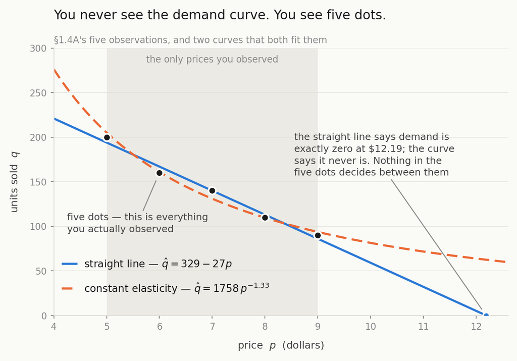

Five dots. Both curves fit them. The data does not choose between them — and outside $5–$9 they disagree.

## Log-Log Regression: Direct Elasticity

Transform both variables with natural log:

$$\ln Q = \beta_0 + \beta_1 \ln P + u$$

**Warning**

**$\varepsilon$ is the elasticity in this lecture — never the error.** Most textbooks write the regression error as $\varepsilon$; we cannot, because $|\varepsilon|$ has already meant the **elasticity** since the first slide. Two different objects, one symbol, and mixing them is the easiest way to misread this deck. Here: **$\varepsilon$ = elasticity, $u$ = error term.**

$$\beta_1 = \frac{d \ln Q}{d \ln P} = \frac{dQ/Q}{dP/P} = \varepsilon$$

$\beta_1$ and $\varepsilon$ are **the same number** — $\varepsilon$ is the economics name, $\beta_1$ is what the regression prints.

$\beta_1$ **is** the price elasticity — constant at every price point.

**Elastic:** $|\varepsilon| > 1$  
→ 1% price increase → >1% quantity drop  
→ Revenue **falls**

**Inelastic:** $|\varepsilon| < 1$  
→ 1% price increase → <1% quantity drop  
→ Revenue **rises**

## Why Logs: the Slope Becomes the Elasticity

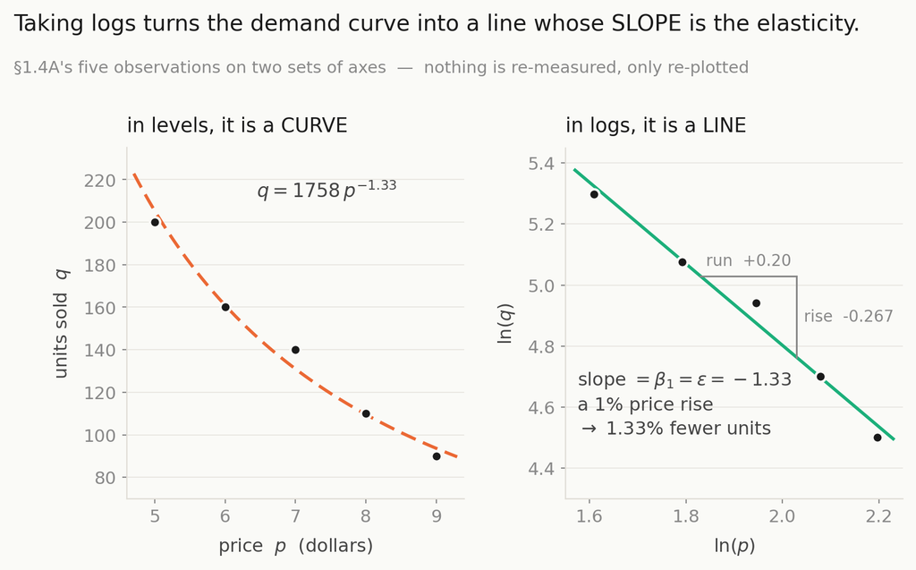

Same five observations, re-plotted — not re-measured. The slope on the right **is** $\varepsilon$.

## Revenue Maximization

Revenue: $R = P \times Q(P)$

$$\frac{dR}{dP} = Q + P\frac{dQ}{dP} = Q\!\left(1 + \frac{P}{Q}\frac{dQ}{dP}\right) = Q(1 + \varepsilon) = 0$$

$$\boxed{\varepsilon = -1 \quad \Longleftrightarrow \quad \text{revenue is maximized (unit-elastic)}}$$

$|\varepsilon| > 1$: lower price raises revenue  
$|\varepsilon| < 1$: raise price, revenue goes up

At the optimal price:  
elastic on one side,  
inelastic on the other

**Warning**

**These two slides assume different things.** The difference is visible in the two elasticity formulas:

|  | elasticity | at a different price? |
| --- | --- | --- |
| **log-log** | $\varepsilon = \beta_1$ | **same** — no $P$ in the formula |
| **levels** | $\varepsilon = \hat{\beta}_1 \times P/Q$ | **changes** — $P/Q$ moves |

So a strict log-log model never turns: if $|\varepsilon| \neq 1$ revenue rises (or falls) without limit. An interior optimum needs elasticity that **varies**. **Report** $\varepsilon$ from log-log; **locate** a revenue-maximising price on the levels fit, and only inside the prices you observed.

## Revenue Peaks Exactly Where $|\varepsilon| = 1$

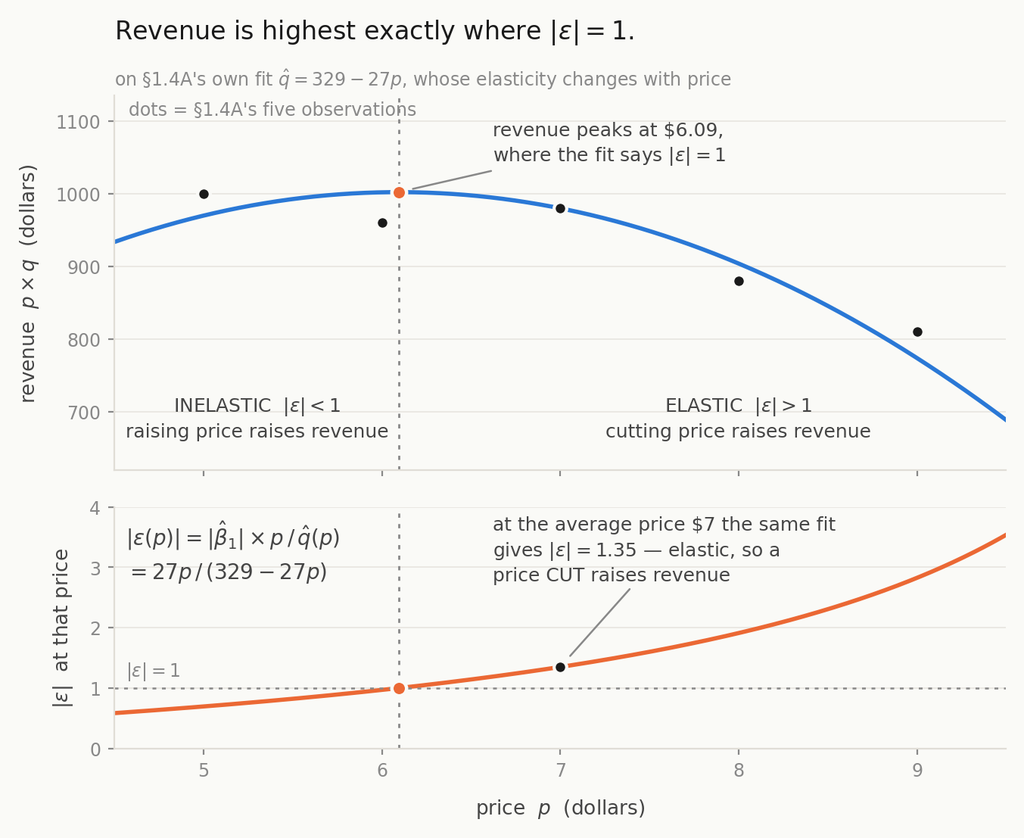

Drawn on $\hat{q} = 329 - 27p$, whose elasticity **varies** — at $7 it is $-1.35$, elastic, so a price cut raises revenue. The log-log slide’s $-1.33$ is a **different object**, not a rounding error: one number for the whole range, against this one read at a single price.

## Endogeneity: When OLS Lies

**Problem:** Price and quantity are determined simultaneously.

A product manager raises prices **when demand is strong** (seasonal, holiday). OLS observes high price AND high quantity and incorrectly estimates a positive (or flat) elasticity.

**Warning**

**Endogeneity bias:** OLS $\hat{\beta}_1$ is biased toward zero (or positive) when price is endogenous.

**Note**

**“Biased” is not “noisy”.** Noise is the spread of $\hat{\beta}_1$ across samples, and it shrinks as you collect more data. **Bias is that spread centred on the wrong number** — a million rows give a very precise estimate of the wrong thing. This is why a high $R^2$ does not make an estimate unbiased.

**Fix (reference — not assessed):** Instrumental Variables (IV) — find a variable that shifts price but doesn’t directly affect demand (e.g., input cost changes).

**Assessed:** recognising that endogeneity biases the estimate (hw02 Q17, Quiz 1). **Not assessed:** choosing, justifying or computing an instrument. Recognizing endogeneity is more important than fixing it at this stage.

## Scope and Limitations

**Estimands**

**Identification assumption**

Exogeneity: $\text{Cov}(P_i, u_i) = 0$ — price is uncorrelated with the **error**.  
Violated when prices are set in response to demand shocks (endogeneity). Instrumental variables estimation is required in that case.

For preference recovery in new markets: see Lecture 9 (Conjoint Analysis).

## Checkpoint

1. From the data above, compute $\hat{\beta}_0$ and verify it equals 329.
2. A **different** store’s log-log regression gives $\hat{\beta}_1 = -1.42$ — not the five rows above, which fit $-1.33$. Is demand elastic or inelastic? What happens to revenue if price rises 5%?
3. At what elasticity is revenue maximized? What does the firm do if current $\varepsilon = -0.8$?
4. A pricing analyst runs OLS on transaction data and gets $\hat{\beta}_1 = +3$ (positive!). What’s the most likely explanation?
5. Why does log-log give a constant elasticity but level-level gives a varying elasticity?

Answers in the lecture notes, under “Slide Checkpoint Answers” (numbered to match this slide).